# Figure 3 script

By: Claire Gonzales

2022-06-17

### Description

**OBJECTIVE**: This will be a spatial visualization of where co-location is being considered. Current plan is to use R to only create the data frame that we need and then use tableau to create the visualization (hopefully.)

**REFLECTIONS**: This was a bit of a wild ride but I think we are on the right track now. I tried using some r tools for this visualization but I think Tableau is nicer and was a bit easier to handle. Working Tableau visualization is [here](https://public.tableau.com/app/profile/claire.gonzales/viz/synthesis_figure3_polygons/Dashboard1?publish=yes)

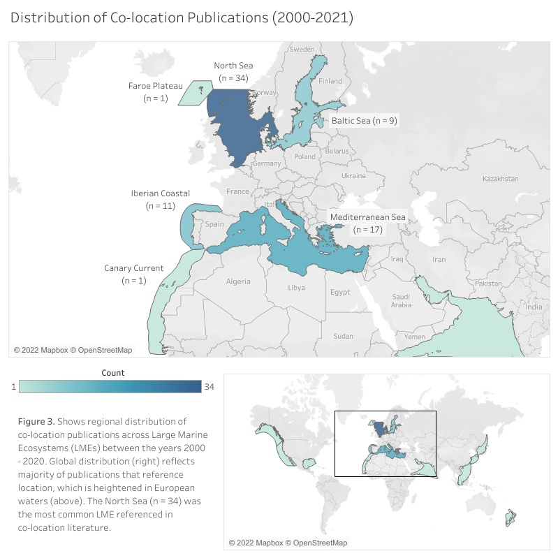

```r
knitr::include_graphics(here("figures", "fig3_tableau.jpg"))
```

### Reading in Data

Data contains ‘orphans’.

```r
mydata <- read_csv(here("data", "Data_total_working_for_r.csv"))
```

### Wrangling

We have figured out the code for this section a couple months ago in the lme_code.Rmd script to put the necessary lme data into tidy format.

```r
lme_clean <- mydata %>%
  select(id, lme1, lme2, lme3, lme4, lme5, lme6)

lme_tidy <- lme_clean %>%
  gather("df", "lme", 2:7, na.rm = TRUE) %>% # output at this stage was QC'd to make sure that the code worked (it did!)
  group_by(lme) %>%
  summarize (
    count = n()
  )

# this output shows each lme (by name) and how many times that lme is referenced in the literature. North Sea far in the lead, being mentioned 34 times.

# > class(lme_tidy$lme)
# [1] "character"
# > class(lme_tidy$count)
# [1] "integer"

# classes might have to be changed to factor and numeric in future
```

```r
write.csv(lme_tidy, here("data", "lme_tidy.csv"))
```

### Tableau Viz

Tableau figure can be found here: https://public.tableau.com/app/profile/claire.gonzales/viz/synthesis_figure3/Sheet3

Honestly, I don’t love it? I feel like it falls a little flat.

### R Viz

I am going to try my hand at an r visualization using `geom_sf` to see if I can create something a little better that way.

```r
# install.packages(c("cowplot", "googleway", "ggplot2", "ggrepel", "ggspatial", "libwgeom", "sf", "rnaturalearth", "rnaturalearthdata"))

library("ggplot2")
theme_set(theme_bw())
library("sf")
library("rnaturalearth")
library("rnaturalearthdata")
```

Let’s load some data.

```r
world <- ne_countries(scale = "medium", returnclass = "sf")
# this provides a map of countries of the entire world. Use ne_countries to pull country data and choose the scale

locations <- read_csv(here("data", "lme_tidy_location.csv"))
# this is the locations of the lmes (not a shapefile)
```

And now try to make a preliminary map

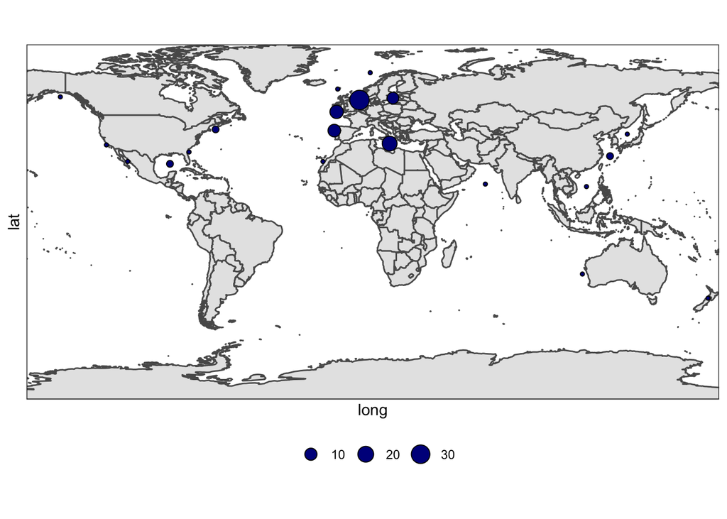

```r
# map1 <-

ggplot(data = world) +
  geom_sf() +
  geom_point(data = locations, aes(x = long, y = lat, size = count), shape = 21, fill = "darkblue") +
  coord_sf(xlim = c(-160, 179), expand = FALSE) +
  theme(legend.title = element_blank(), legend.position= 'bottom')
```

This is a fine approach. Visually, I still think the tableau version is better. I tried adjusting the x and y limits to zoom in a bit, but keep getting an error message for the ylim. I am going to try adding a second pane. Via tableau I will try to add an inset.

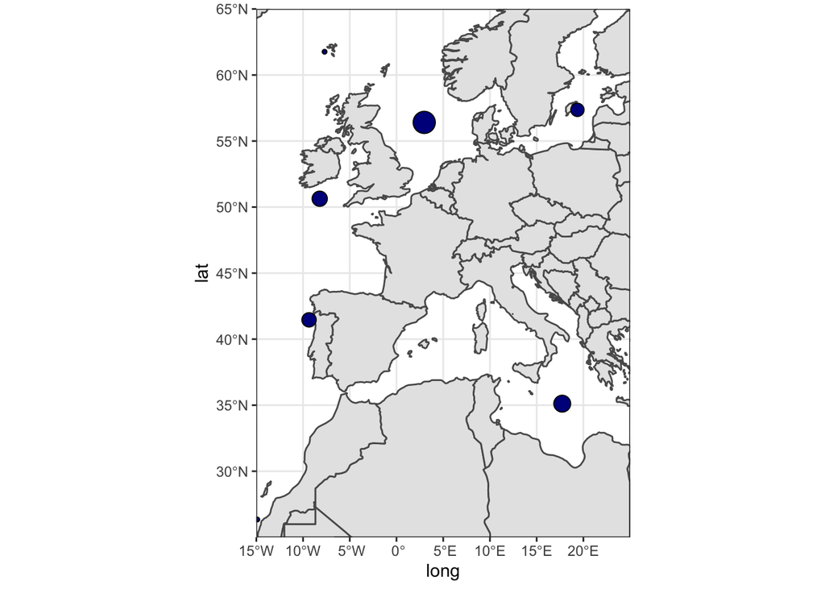

```r
# map2 <-

ggplot(data = world) +
  geom_sf() +
  geom_point(data = locations, aes(x = long, y = lat, size = count), shape = 21, fill = "darkblue") +
  coord_sf(xlim = c(-15, 25), ylim = c(25, 65), expand = FALSE) +
  theme(legend.position="none")
```